# 데이터마이닝의 이론과 실제 중간고사 연습문제

# 연습문제1

# K대학에서는 재학생을 대상으로 교육과정에 대한 현황조사를 실시하였다.

# 학년에 따라 비교과운영 점수가 차이가 있는 가?

```r
R.version
```

```
##                _
## platform       i386-w64-mingw32
## arch           i386
## os             mingw32
## system         i386, mingw32
## status
## major          4
## minor          1.3
## year           2022
## month          03
## day            10
## svn rev        81868
## language       R
## version.string R version 4.1.3 (2022-03-10)
## nickname       One Push-Up
```

# 1.기본 package 설정

# 1.1 library 로드

```r
library(tidyverse)
library(tidymodels)
library(rstatix)
library(skimr)
```

# 2.데이터 불러오기

```r
edu_tb <- read_csv('data1.csv',
                   col_names = TRUE,
                   locale=locale('ko', encoding='euc-kr'), # 한글
                   na=".") %>%
  round(2) %>%                 # 소수점 2자리로 반올림
  mutate_if(is.character, as.factor) %>%
  mutate(학년 = factor(학년,
                        levels=c(1:4),
                        labels=c("1학년","2학년","3학년","4학년")))
str(edu_tb)
```

```
## tibble [286 x 6] (S3: tbl_df/tbl/data.frame)
##  $ 학부        : num [1:286] 1 1 1 1 1 1 1 1 2 2 ...
##  $ 학년        : Factor w/ 4 levels "1학년","2학년",..: 1 1 1 1 1 1 1 1 1 1 ...
##  $ 교양강의운영: num [1:286] 47.6 33.3 50 35.7 54.7 39.3 46.4 42.9 42.9 32.1 ...
##  $ 전공강의운영: num [1:286] 40.5 35.7 52.4 28.5 92.8 53.6 46.4 67.9 50 28.6 ...
##  $ 비교과운영  : num [1:286] 40 33.3 50 40 43.3 55 45 35 25 30 ...
##  $ 종합점수    : num [1:286] 46.7 33.6 50.4 36.1 56.2 48.9 46.9 53.2 37.4 31.5 ...
```

```r
edu_tb
```

```
## # A tibble: 286 x 6
##     학부 학년  교양강의운영 전공강의운영 비교과운영 종합점수
##    <dbl> <fct>        <dbl>        <dbl>      <dbl>    <dbl>
##  1     1 1학년         47.6         40.5       40       46.7
##  2     1 1학년         33.3         35.7       33.3     33.6
##  3     1 1학년         50           52.4       50       50.4
##  4     1 1학년         35.7         28.5       40       36.1
##  5     1 1학년         54.7         92.8       43.3     56.2
##  6     1 1학년         39.3         53.6       55       48.9
##  7     1 1학년         46.4         46.4       45       46.9
##  8     1 1학년         42.9         67.9       35       53.2
##  9     2 1학년         42.9         50         25       37.4
## 10     2 1학년         32.1         28.6       30       31.5
## # ... with 276 more rows
```

```r
tail(edu_tb)
```

```
## # A tibble: 6 x 6
##    학부 학년  교양강의운영 전공강의운영 비교과운영 종합점수
##   <dbl> <fct>        <dbl>        <dbl>      <dbl>    <dbl>
## 1     4 4학년         61.9         83.3       50       68.3
## 2     4 4학년         73.8         83.3       53.3     47.6
## 3     4 4학년         76.1         80.9       80       75.1
## 4     4 4학년         52.4         50         36.6     53.6
## 5     4 4학년         69           80.9       73.3     72.8
## 6     4 4학년         47.6         54.7       56.6     48.3
```

# 3.기술통계분석

```r
skim(edu_tb)
```

Data summary

| Name | edu_tb |
| --- | --- |
| Number of rows | 286 |
| Number of columns | 6 |
| _______________________ |  |
| Column type frequency: |  |
| factor | 1 |
| numeric | 5 |
| ________________________ |  |
| Group variables | None |

**Variable type: factor**

| skim_variable | n_missing | complete_rate | ordered | n_unique | top_counts |
| --- | --- | --- | --- | --- | --- |
| 학년 | 0 | 1 | FALSE | 4 | 2학년: 97, 4학년: 72, 3학년: 67, 1학년: 50 |

**Variable type: numeric**

| skim_variable | n_missing | complete_rate | mean | sd | p0 | p25 | p50 | p75 | p100 | hist |
| --- | --- | --- | --- | --- | --- | --- | --- | --- | --- | --- |
| 학부 | 0 | 1 | 2.85 | 1.02 | 1 | 2.00 | 3.0 | 4.00 | 4 | ▃▆▁▇▇ |
| 교양강의운영 | 0 | 1 | 50.33 | 19.58 | 0 | 40.40 | 50.0 | 58.90 | 100 | ▁▃▇▂▁ |
| 전공강의운영 | 0 | 1 | 55.84 | 20.76 | 0 | 45.50 | 50.0 | 68.72 | 100 | ▁▂▇▃▂ |
| 비교과운영 | 0 | 1 | 46.65 | 19.99 | 0 | 35.00 | 50.0 | 56.60 | 100 | ▂▅▇▃▁ |
| 종합점수 | 0 | 1 | 51.21 | 16.34 | 0 | 41.73 | 49.7 | 60.00 | 100 | ▁▂▇▃▁ |

```r
edu_tb %>%
  group_by(학년) %>%
  get_summary_stats(비교과운영)
```

```
## # A tibble: 4 x 14
##   학년  variable       n   min   max median    q1    q3   iqr   mad  mean    sd
##   <fct> <chr>      <dbl> <dbl> <dbl>  <dbl> <dbl> <dbl> <dbl> <dbl> <dbl> <dbl>
## 1 1학년 비교과운영    50     0 100     41.6  30.8  50    19.2  12.4  40.4  17.6
## 2 2학년 비교과운영    97     0  93.3   46.6  35    56.6  21.6  17.2  45.7  21.3
## 3 3학년 비교과운영    67     0 100     50    43.3  63.3  20    14.8  52.5  19.7
## 4 4학년 비교과운영    72     0  93.3   50    36.6  56.6  20    14.8  46.8  18.7
## # ... with 2 more variables: se <dbl>, ci <dbl>
```

# 4.그래프 그리기(박스그래프,히스토그램)

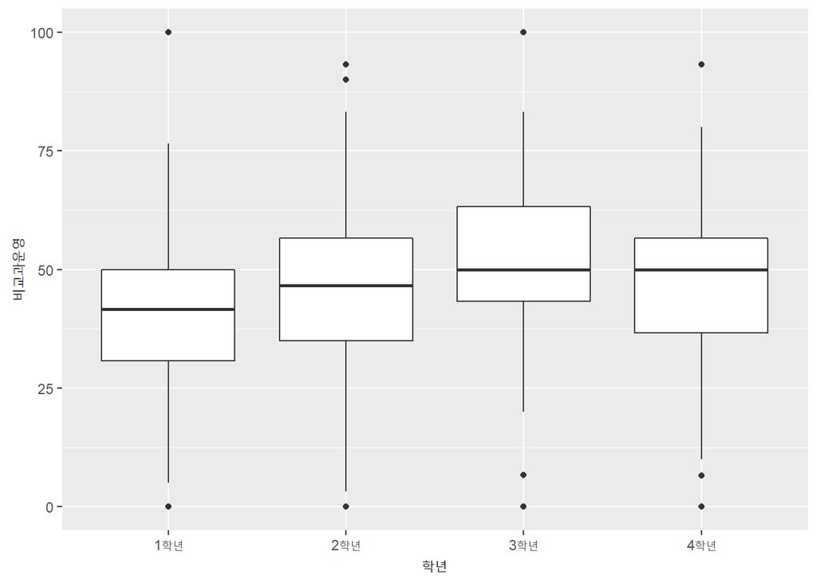

```r
edu_tb %>%
  ggplot(mapping = aes(x = 학년,
                       y = 비교과운영)) +
  geom_boxplot() +
  labs(y = "비교과운영")
```

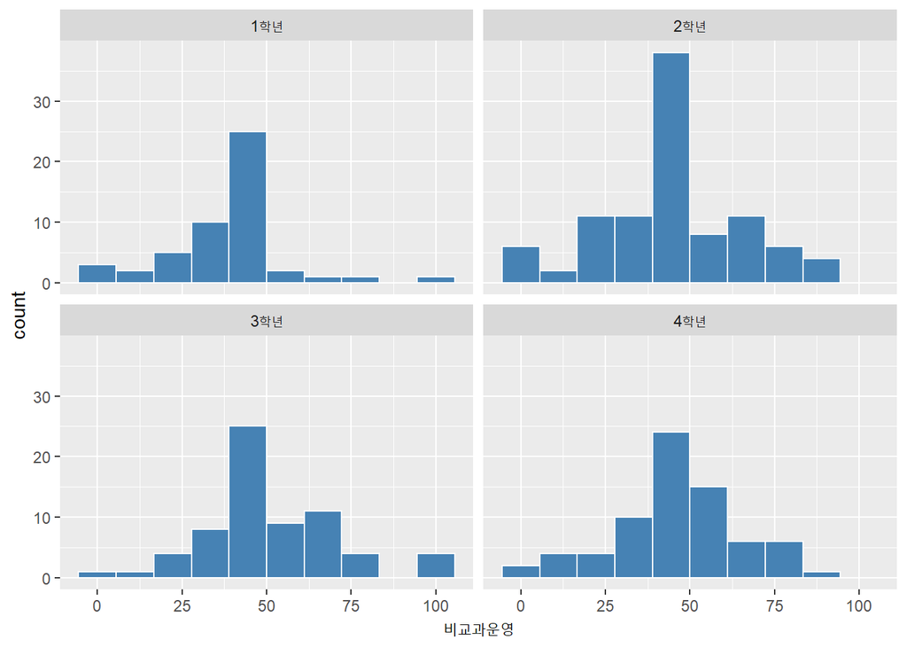

```r
edu_tb %>%
  ggplot(mapping = aes(x = 비교과운영)) +
  geom_histogram(bins = 10,               # binwidth=1,000: 값차이
                 color = "white",
                 fill = "steelblue") +
  facet_wrap(~학년)
```

```r
  #facet_wrap(학부~ 학년)                   # 그룹별 분리
```

# 5.이상치 제거

# 이상치 확인

```r
edu_tb %>%
  select(학년, 비교과운영) %>%
  group_by(학년) %>%
  identify_outliers(비교과운영) %>%
  print(n=50)
```

```
## # A tibble: 23 x 4
##    학년  비교과운영 is.outlier is.extreme
##    <fct>      <dbl> <lgl>      <lgl>
##  1 1학년        0   TRUE       FALSE
##  2 1학년      100   TRUE       FALSE
##  3 1학년        0   TRUE       FALSE
##  4 2학년       90   TRUE       FALSE
##  5 2학년        0   TRUE       FALSE
##  6 2학년       93.3 TRUE       FALSE
##  7 2학년        0   TRUE       FALSE
##  8 2학년        0   TRUE       FALSE
##  9 2학년        0   TRUE       FALSE
## 10 2학년        0   TRUE       FALSE
## 11 2학년       90   TRUE       FALSE
## 12 2학년       93.3 TRUE       FALSE
## 13 3학년      100   TRUE       FALSE
## 14 3학년      100   TRUE       FALSE
## 15 3학년      100   TRUE       FALSE
## 16 3학년      100   TRUE       FALSE
## 17 3학년        0   TRUE       FALSE
## 18 3학년        6.7 TRUE       FALSE
## 19 4학년        0   TRUE       FALSE
## 20 4학년       93.3 TRUE       FALSE
## 21 4학년        6.6 TRUE       FALSE
## 22 4학년        6.6 TRUE       FALSE
## 23 4학년        0   TRUE       FALSE
```

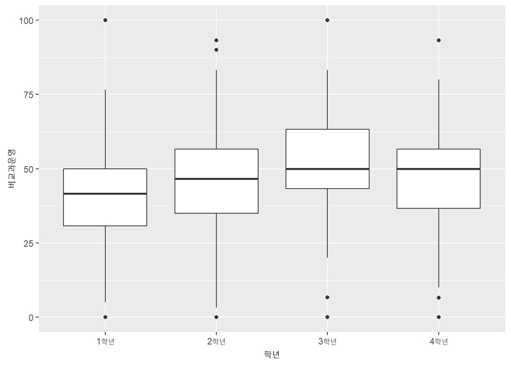

```r
edu_tb %>%
  ggplot(mapping = aes(x = 학년,
                       y = 비교과운영)) +
  geom_boxplot() +
  labs(y = "비교과운영")
```

# !은 제외한 나머지 모두를 가져올때 사용함

```r
edu_tb <- edu_tb %>%
  filter(!(비교과운영 <= 10 | 비교과운영 >= 100)) %>%
  filter(!(학년 == "1학년" & 비교과운영 >= 76.6 )) %>%
  filter(!(학년 == "2학년" & 비교과운영 >= 83.3)) %>%
  filter(!(학년 == "4학년" & 비교과운영 >= 93.3))
```

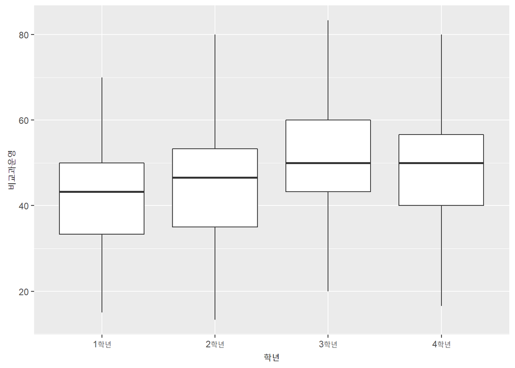

```r
edu_tb %>%
  ggplot(mapping = aes(x = 학년,
                       y = 비교과운영)) +
  geom_boxplot() +
  labs(y = "비교과운영")
```

# 6.정규분포 검정 ,모든학년이 p값이 0.05 보다 크므로 정규분포를 따른다.

```r
edu_tb %>%
  group_by(학년) %>%
  shapiro_test(비교과운영)
```

```
## # A tibble: 4 x 4
##   학년  variable   statistic      p
##   <fct> <chr>          <dbl>  <dbl>
## 1 1학년 비교과운영     0.950 0.0502
## 2 2학년 비교과운영     0.975 0.0999
## 3 3학년 비교과운영     0.979 0.375
## 4 4학년 비교과운영     0.975 0.204
```

if(0)" null hypothesis(H0; 귀무가설) 는 데이터가 정규분포를 따른다 이고, Alternative hypothesis(H1; 대립가설) 은 데이터가 정규분포를 따르지 않는다 이다. 이렇게 획득한 shapiro-wilk test 결과, p-value 가 0.05 보다 작을 경우 귀무가설을 reject하고 대립가설을 채택; p-value 가 0.05보다 클 경우 대립가설을 reject하고 귀무가설을 채택 "

# 7.등분산 검정 (대상 집단의 분산이 같은지 다른지를 통계적으로 검정하는 방법)

# 이분산일때는 하단의 Welch’s ANOVA test 참조

```r
edu_tb %>%
  levene_test(비교과운영 ~ 학년)  # levene_test p값이 0.05이하이면 이분산 Welch's ANOVA test 사용함
```

```
## # A tibble: 1 x 4
##     df1   df2 statistic     p
##   <int> <int>     <dbl> <dbl>
## 1     3   253      1.04 0.375
```

> 귀무가설(H0): 모든 집단의 분산은 차이가 없다. 대립가설(H1): 적어도 하나 이상의 집단의 분산에 차이가 있다. 등분산 검정의 결과 유의값(p-value)이 .05 미만인 경우에는 대립가설을 지지하여 ’분산에 차이가 있다.’고 말할 수 있다. 반대로 유의값(p-value)이 .05 이상인 경우에는 귀무가설을 지지하여 ’분산에 차이가 없다.’고 말할 수 있다. R에서 등분산 검정을 수행하는 함수는 levene.test와 bartlett.test가 있다.

# 8.등분산 ANOVA

# 등분산일때 ANOVA분석 (종속변수 ~ 그룹변수)

# p값이 0.05 보다 작으면 대립가설 성립(모든 그룹의 평균이 같지 않다,)

```r
owa_result <- aov(비교과운영 ~ 학년,
                     data=edu_tb)
```

```r
tidy(owa_result)
```

```
## # A tibble: 2 x 6
##   term         df  sumsq meansq statistic  p.value
##   <chr>     <dbl>  <dbl>  <dbl>     <dbl>    <dbl>
## 1 학년          3  3185.  1062.      5.26  0.00154
## 2 Residuals   253 51036.   202.     NA    NA
```

```r
summary(owa_result)
```

```
##              Df Sum Sq Mean Sq F value  Pr(>F)
## 학년          3   3185  1061.7   5.263 0.00154 **
## Residuals   253  51036   201.7
## ---
## Signif. codes:  0 '***' 0.001 '**' 0.01 '*' 0.05 '.' 0.1 ' ' 1
```

```r
edu_tb %>%
  anova_test(비교과운영 ~ 학년)
```

```
## Coefficient covariances computed by hccm()
```

```
## ANOVA Table (type II tests)
##
##   Effect DFn DFd     F     p p<.05   ges
## 1   학년   3 253 5.263 0.002     * 0.059
```

# Cohen’s d(effect size) 두 집단의 평균 차이를 일정한 기준으로 표현한 것

# 0.2 (small effect), 0.5 (moderate effect) and 0.8 (large effect)

```r
edu_tb %>%
  cohens_d(formula = 비교과운영 ~ 학년,
           var.equal = TRUE)
```

```
## # A tibble: 6 x 7
##   .y.        group1 group2 effsize    n1    n2 magnitude
## * <chr>      <chr>  <chr>    <dbl> <int> <int> <ord>
## 1 비교과운영 1학년  2학년   -0.351    45    85 small
## 2 비교과운영 1학년  3학년   -0.788    45    61 moderate
## 3 비교과운영 1학년  4학년   -0.642    45    66 moderate
## 4 비교과운영 2학년  3학년   -0.349    85    61 small
## 5 비교과운영 2학년  4학년   -0.234    85    66 small
## 6 비교과운영 3학년  4학년    0.118    61    66 negligible
```

# 등분산(2개의 모집단(Population) 에서 추출된 각 sample 간의 분산이 같음)이 성립되므로 Fisher LSD 실행시킴

# 9.사후검정(Multicamparison test ),(post hoc)

# Fisher LSD(Least Significant Difference = “최소한의 유의미한 차이”)

```r
edu_tb %>%
  pairwise_t_test(비교과운영 ~ 학년,
                     p.adj="non")
```

```
## # A tibble: 6 x 9
##   .y.        group1 group2    n1    n2        p p.signif    p.adj p.adj.signif
## * <chr>      <chr>  <chr>  <int> <int>    <dbl> <chr>       <dbl> <chr>
## 1 비교과운영 1학년  2학년     45    85 0.0566   ns       0.0566   ns
## 2 비교과운영 1학년  3학년     45    61 0.000311 ***      0.000311 ***
## 3 비교과운영 2학년  3학년     85    61 0.0303   *        0.0303   *
## 4 비교과운영 1학년  4학년     45    66 0.0021   **       0.0021   **
## 5 비교과운영 2학년  4학년     85    66 0.133    ns       0.133    ns
## 6 비교과운영 3학년  4학년     61    66 0.508    ns       0.508    ns
```

# Bonferroni

```r
edu_tb %>%
  pairwise_t_test(비교과운영 ~ 학년,
                     p.adj="bonferroni")
```

```
## # A tibble: 6 x 9
##   .y.        group1 group2    n1    n2        p p.signif   p.adj p.adj.signif
## * <chr>      <chr>  <chr>  <int> <int>    <dbl> <chr>      <dbl> <chr>
## 1 비교과운영 1학년  2학년     45    85 0.0566   ns       0.34    ns
## 2 비교과운영 1학년  3학년     45    61 0.000311 ***      0.00187 **
## 3 비교과운영 2학년  3학년     85    61 0.0303   *        0.182   ns
## 4 비교과운영 1학년  4학년     45    66 0.0021   **       0.0126  *
## 5 비교과운영 2학년  4학년     85    66 0.133    ns       0.795   ns
## 6 비교과운영 3학년  4학년     61    66 0.508    ns       1       ns
```

# Tukey HSD

```r
owa_result %>%
  TukeyHSD() %>%
  tidy()
```

```
## # A tibble: 6 x 7
##   term  contrast    null.value estimate conf.low conf.high adj.p.value
##   <chr> <chr>            <dbl>    <dbl>    <dbl>     <dbl>       <dbl>
## 1 학년  2학년-1학년          0     5.01   -1.76      11.8      0.224
## 2 학년  3학년-1학년          0    10.2     2.99      17.4      0.00176
## 3 학년  4학년-1학년          0     8.53    1.43      15.6      0.0112
## 4 학년  3학년-2학년          0     5.19   -0.973     11.4      0.132
## 5 학년  4학년-2학년          0     3.52   -2.51       9.54     0.434
## 6 학년  4학년-3학년          0    -1.67   -8.20       4.85     0.911
```

# 학년으로 표현

# install.packages(“agricolae”)

```r
library(agricolae)
```

# console=TRUE: 결과를 화면에 표시

# 학년=TRUE: 그룹으로 묶어서 표시, FALSE: 1:1로 비교

# LSD.test, duncan.test, scheffe.test

```r
owa_result %>%
  LSD.test("학년",
           group=FALSE,
           console = TRUE)
```

```
##
## Study: . ~ "학년"
##
## LSD t Test for 비교과운영
##
## Mean Square Error:  201.7226
##
## 학년,  means and individual ( 95 %) CI
##
##       비교과운영      std  r      LCL      UCL  Min  Max
## 1학년   40.81111 11.54500 45 36.64144 44.98078 15.0 70.0
## 2학년   45.82588 15.50789 85 42.79200 48.85976 13.3 80.0
## 3학년   51.01639 13.90427 61 47.43508 54.59771 20.0 83.3
## 4학년   49.34242 14.34192 66 45.89943 52.78542 16.6 80.0
##
## Alpha: 0.05 ; DF Error: 253
## Critical Value of t: 1.969385
##
## Comparison between treatments means
##
##               difference pvalue signif.        LCL        UCL
## 1학년 - 2학년  -5.014771 0.0566       . -10.171375  0.1418329
## 1학년 - 3학년 -10.205282 0.0003     *** -15.701825 -4.7087398
## 1학년 - 4학년  -8.531313 0.0021      ** -13.938746 -3.1238807
## 2학년 - 3학년  -5.190511 0.0303       *  -9.884152 -0.4968699
## 2학년 - 4학년  -3.516542 0.1325          -8.105508  1.0724245
## 3학년 - 4학년   1.673969 0.5076          -3.293930  6.6418688
```

```r
owa_result %>%
  LSD.test("학년",
           group=TRUE,
           console = TRUE)
```

```
##
## Study: . ~ "학년"
##
## LSD t Test for 비교과운영
##
## Mean Square Error:  201.7226
##
## 학년,  means and individual ( 95 %) CI
##
##       비교과운영      std  r      LCL      UCL  Min  Max
## 1학년   40.81111 11.54500 45 36.64144 44.98078 15.0 70.0
## 2학년   45.82588 15.50789 85 42.79200 48.85976 13.3 80.0
## 3학년   51.01639 13.90427 61 47.43508 54.59771 20.0 83.3
## 4학년   49.34242 14.34192 66 45.89943 52.78542 16.6 80.0
##
## Alpha: 0.05 ; DF Error: 253
## Critical Value of t: 1.969385
##
## Groups according to probability of means differences and alpha level( 0.05 )
##
## Treatments with the same letter are not significantly different.
##
##       비교과운영 groups
## 3학년   51.01639      a
## 4학년   49.34242     ab
## 2학년   45.82588     bc
## 1학년   40.81111      c
```

```r
owa_result %>%
  duncan.test("학년",
              group=TRUE,
              console = TRUE)
```

```
##
## Study: . ~ "학년"
##
## Duncan's new multiple range test
## for 비교과운영
##
## Mean Square Error:  201.7226
##
## 학년,  means
##
##       비교과운영      std  r  Min  Max
## 1학년   40.81111 11.54500 45 15.0 70.0
## 2학년   45.82588 15.50789 85 13.3 80.0
## 3학년   51.01639 13.90427 61 20.0 83.3
## 4학년   49.34242 14.34192 66 16.6 80.0
##
## Groups according to probability of means differences and alpha level( 0.05 )
##
## Means with the same letter are not significantly different.
##
##       비교과운영 groups
## 3학년   51.01639      a
## 4학년   49.34242      a
## 2학년   45.82588     ab
## 1학년   40.81111      b
```

```r
owa_result %>%
  duncan.test("학년",
              group=FALSE,
              console = TRUE)
```

```
##
## Study: . ~ "학년"
##
## Duncan's new multiple range test
## for 비교과운영
##
## Mean Square Error:  201.7226
##
## 학년,  means
##
##       비교과운영      std  r  Min  Max
## 1학년   40.81111 11.54500 45 15.0 70.0
## 2학년   45.82588 15.50789 85 13.3 80.0
## 3학년   51.01639 13.90427 61 20.0 83.3
## 4학년   49.34242 14.34192 66 16.6 80.0
##
## Comparison between treatments means
##
##               difference pvalue signif.        LCL         UCL
## 1학년 - 2학년  -5.014771 0.0522       . -10.077902  0.04835986
## 1학년 - 3학년 -10.205282 0.0002     *** -15.713309 -4.69725579
## 1학년 - 4학년  -8.531313 0.0015      ** -13.861222 -3.20140464
## 2학년 - 3학년  -5.190511 0.0565       . -10.520420  0.13939740
## 2학년 - 4학년  -3.516542 0.1726          -8.579673  1.54658922
## 3학년 - 4학년   1.673969 0.5156          -3.389162  6.73710031
```

```r
owa_result %>%
  scheffe.test("학년",
               group=TRUE,
               console = TRUE)
```

```
##
## Study: . ~ "학년"
##
## Scheffe Test for 비교과운영
##
## Mean Square Error  : 201.7226
##
## 학년,  means
##
##       비교과운영      std  r  Min  Max
## 1학년   40.81111 11.54500 45 15.0 70.0
## 2학년   45.82588 15.50789 85 13.3 80.0
## 3학년   51.01639 13.90427 61 20.0 83.3
## 4학년   49.34242 14.34192 66 16.6 80.0
##
## Alpha: 0.05 ; DF Error: 253
## Critical Value of F: 2.640281
##
## Groups according to probability of means differences and alpha level( 0.05 )
##
## Means with the same letter are not significantly different.
##
##       비교과운영 groups
## 3학년   51.01639      a
## 4학년   49.34242      a
## 2학년   45.82588     ab
## 1학년   40.81111      b
```